# Netflix Movies and TV Shows

Puja Handini

2024/06/30

## Introduction

[figure not shown]

Photo by Thibault Panin on Unsplash

### About this Dataset

Netflix is one of the most popular media and video streaming platforms. They have over 8000 movies or tv shows available on their platform, as of mid-2021, they have over 200M Subscribers globally. This tabular dataset consists of listings of all the movies and tv shows available on Netflix, along with details such as - cast, directors, ratings, release year, duration, etc.

### Goals

The goal is to clean the data, do some EDA, make pretty graphs and charts, maybe finally will gain some insight about the data, including:

1. Understanding what content is available in different countries
2. Identifying similar content by matching text-based features
3. Network analysis of Actors / Directors and find interesting insights
4. Does Netflix has more focus on TV Shows than movies in recent years.
5. Has Duration of movies over the years increased or decreased.
6. Compare ratings of TV Shows and Movies and determine how they are rated.

## Data Cleaning

First, let’s just load the data!

```r
# Load data
netflix <- read.csv("netflix_titles.csv")
head(netflix)
```

[output not shown]

[output cut: 20 more lines]

```r
str(netflix)
```

```
## 'data.frame':    8807 obs. of  12 variables:
##  $ show_id     : chr  "s1" "s2" "s3" "s4" ...
##  $ type        : chr  "Movie" "TV Show" "TV Show" "TV Show" ...
##  $ title       : chr  "Dick Johnson Is Dead" "Blood & Water" "Ganglands" "Jailbirds New Orleans" ...
##  $ director    : chr  "Kirsten Johnson" "" "Julien Leclercq" "" ...
##  $ cast        : chr  "" "Ama Qamata, Khosi Ngema, Gail Mabalane, Thabang Molaba, Dillon Windvogel, Natasha Thahane, Arno Greeff, Xolile "| __truncated__ "Sami Bouajila, Tracy Gotoas, Samuel Jouy, Nabiha Akkari, Sofia Lesaffre, Salim Kechiouche, Noureddine Farihi, G"| __truncated__ "" ...
##  $ country     : chr  "United States" "South Africa" "" "" ...
##  $ date_added  : chr  "September 25, 2021" "September 24, 2021" "September 24, 2021" "September 24, 2021" ...
##  $ release_year: int  2020 2021 2021 2021 2021 2021 2021 1993 2021 2021 ...
##  $ rating      : chr  "PG-13" "TV-MA" "TV-MA" "TV-MA" ...
##  $ duration    : chr  "90 min" "2 Seasons" "1 Season" "1 Season" ...
##  $ listed_in   : chr  "Documentaries" "International TV Shows, TV Dramas, TV Mysteries" "Crime TV Shows, International TV Shows, TV Action & Adventure" "Docuseries, Reality TV" ...
##  $ description : chr  "As her father nears the end of his life, filmmaker Kirsten Johnson stages his death in inventive and comical wa"| __truncated__ "After crossing paths at a party, a Cape Town teen sets out to prove whether a private-school swimming star is h"| __truncated__ "To protect his f…
```

And we want to view the summary of dataset before we start cleaning.

```r
summary(netflix)
```

```
##    show_id              type              title             director
##  Length:8807        Length:8807        Length:8807        Length:8807
##  Class :character   Class :character   Class :character   Class :character
##  Mode  :character   Mode  :character   Mode  :character   Mode  :character
##
##
##
##      cast             country           date_added         release_year
##  Length:8807        Length:8807        Length:8807        Min.   :1925
##  Class :character   Class :character   Class :character   1st Qu.:2013
##  Mode  :character   Mode  :character   Mode  :character   Median :2017
##                                                           Mean   :2014
##                                                           3rd Qu.:2019
##                                                           Max.   :2021
##     rating            duration          listed_in         description
##  Length:8807        Length:8807        Length:8807        Length:8807
##  Class :character   Class :character   Class :character   Class :character
##  Mode  :character   Mode  :character   Mode  :character   Mode  :character
##
##
##
```

From the summary above we discovered some columns are not formatted correctly. - type - country - date_added - release_year - rating - listed_in

```r
netflix$type <- as.factor(netflix$type)
netflix$country <- as.factor(netflix$country)
netflix$date_added <- mdy(netflix$date_added)
netflix$release_year <- as.factor(netflix$release_year)
netflix$rating <- as.factor(netflix$rating)
netflix$listed_in <- as.factor(netflix$listed_in)

str(netflix)
```

```
## 'data.frame':    8807 obs. of  12 variables:
##  $ show_id     : chr  "s1" "s2" "s3" "s4" ...
##  $ type        : Factor w/ 2 levels "Movie","TV Show": 1 2 2 2 2 2 1 1 2 1 ...
##  $ title       : chr  "Dick Johnson Is Dead" "Blood & Water" "Ganglands" "Jailbirds New Orleans" ...
##  $ director    : chr  "Kirsten Johnson" "" "Julien Leclercq" "" ...
##  $ cast        : chr  "" "Ama Qamata, Khosi Ngema, Gail Mabalane, Thabang Molaba, Dillon Windvogel, Natasha Thahane, Arno Greeff, Xolile "| __truncated__ "Sami Bouajila, Tracy Gotoas, Samuel Jouy, Nabiha Akkari, Sofia Lesaffre, Salim Kechiouche, Noureddine Farihi, G"| __truncated__ "" ...
##  $ country     : Factor w/ 749 levels "",", France, Algeria",..: 605 428 1 1 253 1 1 665 508 605 ...
##  $ date_added  : Date, format: "2021-09-25" "2021-09-24" ...
##  $ release_year: Factor w/ 74 levels "1925","1942",..: 73 74 74 74 74 74 74 46 74 74 ...
##  $ rating      : Factor w/ 18 levels "","66 min","74 min",..: 9 13 13 13 13 13 8 13 11 9 ...
##  $ duration    : chr  "90 min" "2 Seasons" "1 Season" "1 Season" ...
##  $ listed_in   : Factor w/ 514 levels "Action & Adventure",..: 275 416 243 298 395 502 122 320 115 198 ...
##  $ description : chr  "As her father nears the end of his life, filmmaker Kirsten Johnson stages his death in inventive and comical wa"| __truncated__ "After crossing paths at a party, a Cape Town teen sets out to prove whether a private-school swimming star is h"| __truncated__ "To protect his f…
```

## Explorations

Let us determine whether Netflix has been more focused on TV shows or movies.

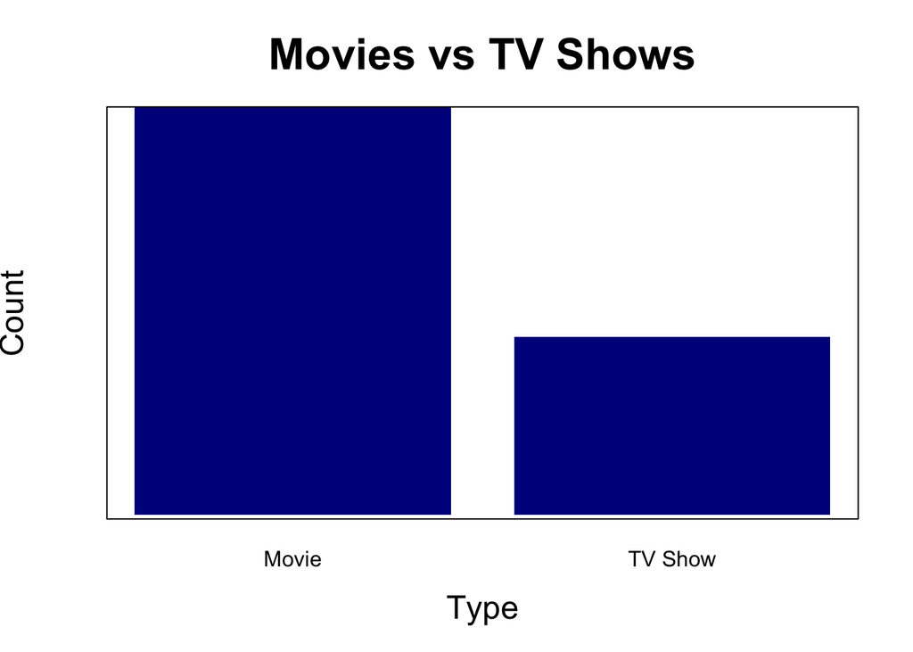

```r
type_counts <- table(netflix$type)

barplot(type_counts,
        main = "Movies vs TV Shows",
        xlab = "Type",
        ylab = "Count",
        col = "dark blue",
        cex.main = 2,
        cex.lab = 1.5,
        border = NA,
        axes = FALSE)

# Adding a box around the plot
box()
```

*Netflix is more focus on Movies*

```r
# Load necessary library
library(dplyr)
# Assuming your data frame is named 'netflix_movies'
movies <- netflix %>%
  filter(type == "Movie") %>%
  filter(country != "") %>%
  group_by(country) %>%
  summarize(number = n()) %>%
  arrange(desc(number)) %>%
  slice(1:10)

# Display the movies data frame
head(movies)
```

```
## # A tibble: 6 × 2
##   country        number
##   <fct>           <int>
## 1 United States    2058
## 2 India             893
## 3 United Kingdom    206
## 4 Canada            122
## 5 Spain              97
## 6 Egypt              92
```

[figure not shown]

```r
# Create a bar plot
# Setting up the margins to accommodate large text
par(mar = c(12, 5, 5, 2)) # Adjust bottom margin to fit long country names

# Create the bar plot
barplot(
  height = movies$number,
  names.arg = movies$country,
  main = "Top Ten Countries - Movies",
  xlab = "",
  ylab = "Number of Movies",
  col = "dark blue",
  las = 2, # Rotate x-axis labels
  cex.names = 10, # Adjust size of x-axis labels
  cex.main = 10, # Adjust size of the title
  cex.lab = 10 # Adjust size of the axis labels
)

# Adding a box around the plot
box()
```